# When is your next inspection?

Prediction of restaurant inspections in NYC

Me.

# 1 Introduction

Food service establishments (FEA’s) in New York City receive an unannounced inspection at least once a year by the Health Department to monitor their compliance with food safety regulations. Recorded violations result in a score, which in turn determines the grade issued. A score from 0 to 13 is an A-Grade, 14 to 27 a B-grade, and scores above 27 result in a C-grade.

FEA’s that receive an A-grade on their first inspection post it immediately. Restaurants that do not receive an A-Grade on their first inspection can improve their sanitary conditions and are re-inspected. If a restaurant does not receive an A-grade on the re-inspection, it must either post the letter-grade or ‘grade pending’.

The goal of this project is to use data on these restaurant inspections to predict the duration until the next inspection occurs.

- CAMIS: a unique identifier for the restaurant
- DBA: name of (doing business as) the restaurant
- BORO: borough in which the restaurant is located
- BUILDING: building number for the restaurant
- STREET: street name at which the restaurant is located
- ZIPCODE: Zip code as per the (mailing) address of the restaurant
- PHONE: phone number
- CUISINE DESCRIPTION: cuisine of the restaurant
- INSPECTION DATE: date of inspection
- ACTION: action associated with the given inspection
- VIOLATION CODE: violation code associated with the given inspection
- VIOLATION DESCRIPTION: description that corresponds to violation code
- CRITICAL FLAG: indication if violation is critical or not
- SCORE: total score for a particular inspection
- GRADE: grade issued for the given inspection
- GRADE DATE: date when the current grade was issued to the restaurant
- RECORD DATE: The date when the extract was run to produce this data set
- INSPECTION TYPE: The type of inspection. A combination of the program and inspection type

```r
df_raw <- read_excel( "New_York_City_Restaurants.xlsx",
                      col_types = c(rep("text", 8),
                                    "date",
                                    rep("text", 4),
                                    "numeric",
                                    "text",
                                    rep("date", 2),
                                    "text"))
```

For convenience, we rename the variables.

```r
df_raw <- df_raw %>%
  clean_names() %>%
  rename(id = camis, rest_name = dba, cuisine_descr = cuisine_description,
           violation_descr = violation_description)
```

# 2 Exploratory Data Analysis

We will start the analysis by computing summary statistics for some of the variables in the data set.

## 2.1 Inspection Date

```r
df_raw <- df_raw %>%
  mutate(inspection_date = ymd(inspection_date))
df_raw %>%
  summarise(min = min(inspection_date),
            median = median(inspection_date),
            max = max(inspection_date))
```

| min | median | max |
| --- | --- | --- |
| 1900-01-01 | 2016-08-10 | 2018-03-19 |

Apparently, there are some observations with an inspection date of “1900-01-01”. Of course, these are faulty values. On closer inspection we see that values for all variables which are related to the inspection at hand are missing.

```r
df_raw %>%
  summarise(na_inspectionDate = round((sum(inspection_date == "1900-01-01")/n()), 4))
```

| na_inspectionDate |
| --- |
| 0.0031 |

Those obervations amount to 0.31 % of all observations. Because it is more convenient, we will exclude them from the subsequent analysis.

```r
df_raw <- df_raw %>%
  filter(!inspection_date == "1900-01-01")
```

As we can see now, the remaining observations range from October 2011 to March 2018:

```r
df_raw %>%
  summarise(min = min(inspection_date),
            median = median(inspection_date),
            max = max(inspection_date))
```

| min | median | max |
| --- | --- | --- |
| 2011-10-11 | 2016-08-12 | 2018-03-19 |

## 2.2 Cuisine description

```r
df_raw <- df_raw %>%
  mutate(cuisine_descr = as_factor(cuisine_descr)) %>%
  # Cuisine_description: Relabel level "CafÃƒÂ©/Coffee/Tea" and "Latin (...
  mutate(cuisine_descr =
             fct_recode(cuisine_descr,
                        Coffee_Tea = "CafÃƒÂ©/Coffee/Tea",
                        Latin = "Latin (Cuban, Dominican, Puerto Rican, South & Central American)")) %>%
  # only keep the 20 most frequent cuisines
  mutate(cuisine_descr = fct_lump(f = cuisine_descr, n = 20))
```

Let us look at the distribution of ‘cuisine_descr’:

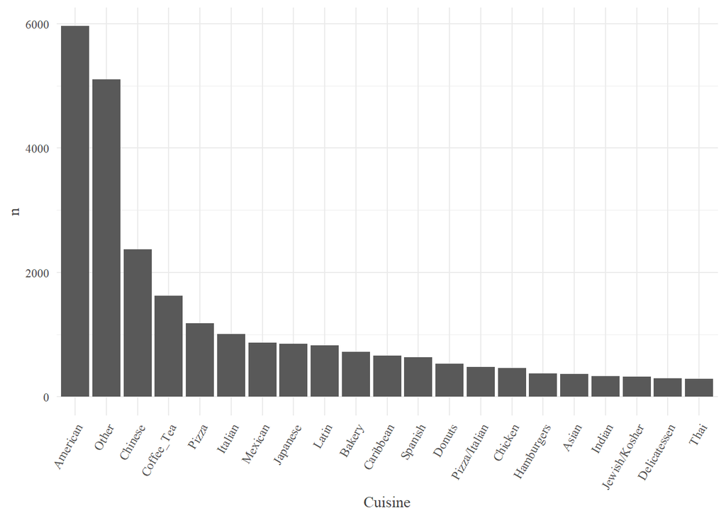

```r
df_raw %>%
  group_by(cuisine_descr) %>%
  summarise(n = n_distinct(id)) %>%
  ungroup() %>%
  ggplot(aes(x = reorder(cuisine_descr, -n), y = n)) +
  geom_bar(stat = "identity") +
  xlab("Cuisine") +
  theme_minimal() +
  theme(
    text = element_text(
      family = "serif",
      color = "gray25"
    ),
    axis.text.x = element_text(angle = 60, hjust = 1)
  )
```

The most frequent cuisines are those labelled ‘American’, ‘Other’ and ‘Chinese’.

## 2.3 Boros

Next, let us take a look at the distribution of ‘Boro’.

```r
df_raw <- df_raw %>%
  mutate(boro = na_if(boro, "Missing")) %>%
  mutate(boro = as_factor(boro))

df_raw %>%
  count(boro)
```

| boro | n |
| --- | --- |
| MANHATTAN | 149821 |
| BROOKLYN | 94772 |
| QUEENS | 85191 |
| BRONX | 33105 |
| STATEN ISLAND | 12900 |

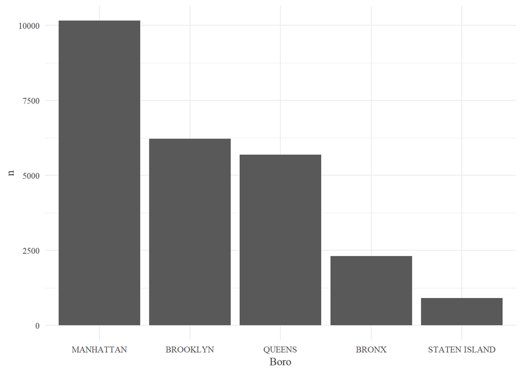

```r
df_raw %>%
  group_by(boro) %>%
  summarize(n = n_distinct(id)) %>%
  ggplot(aes(x = reorder(boro, -n), y = n)) +
  geom_bar(stat = "identity") +
  theme(axis.text.x = element_text(angle=60, hjust=1)) +
  xlab("Boro") +
  theme_minimal() +
  theme(
    text = element_text(
      family = "serif",
      color = "gray25"
    )
  )
```

Most of the food service establishments are located in Manhattan, followed by Brooklyn and Queens.

## 2.4 Actions taken

Next, we look at the variable ‘actions taken’, which describes the action carried out by the DOHMH. The variable takes on the following values:

```r
df_raw <- df_raw %>%
  mutate(action = as_factor(action))

df_raw %>%
  distinct(action)
```

| action |
| --- |
| Violations were cited in the following area(s). |
| Establishment re-opened by DOHMH |
| Establishment Closed by DOHMH. Violations were cited in the following area(s) and those requiring immediate action were addressed. |
| No violations were recorded at the time of this inspection. |
| Establishment re-closed by DOHMH |

We rename its levels for convenience:

```r
df_raw <- df_raw %>%
    mutate(action = fct_recode(action,
                               YesViol = "Violations were cited in the following area(s).",
                               ReOpened = "Establishment re-opened by DOHMH",
                               Closed = "Establishment Closed by DOHMH.  Violations were cited in the following area(s) and those requiring immediate action were addressed.",
                               NoViol = "No violations were recorded at the time of this inspection.",
                               ReClosed = "Establishment re-closed by DOHMH"))

df_raw %>%
  distinct(action)
```

| action |
| --- |
| YesViol |
| ReOpened |
| Closed |
| NoViol |
| ReClosed |

Let us have a look at the frequencies of the levels of ‘action’.

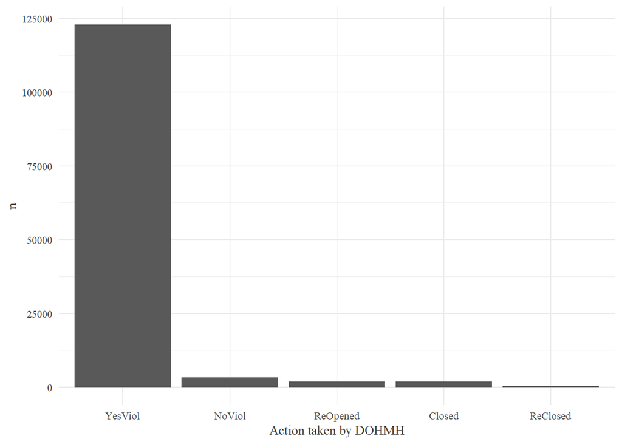

```r
df_raw %>%
  group_by(id, inspection_date) %>%
  summarise(action_taken = first(action)) %>%
  group_by(action_taken) %>%
  summarise(n = n()) %>%
  ggplot(aes(x = reorder(action_taken, -n), y = n)) +
  geom_bar(stat = "identity") +
  xlab("Action taken by DOHMH") +
  theme_minimal() +
  theme(
    text = element_text(
      family = "serif",
      color = "gray25"
    )
  )
```

The most frequent category is ‘YesViol’, i.e., in the majority of inspections there were violations.

## 2.5 Violation types

Next, we will consider the different types of violations recorded. The most common violation codes are listed below:

```r
df_raw %>%
  mutate(violation_code = as_factor(violation_code)) %>%
  group_by(violation_code) %>%
  summarise(number = n()) %>%
  mutate(rank = rank(desc(number))) %>%
  filter(rank <= 10) %>%
  arrange(rank)
```

| violation_code | number | rank |
| --- | --- | --- |
| 10F | 53154 | 1 |
| 08A | 38706 | 2 |
| 04L | 26768 | 3 |
| 06C | 25521 | 4 |
| 06D | 25215 | 5 |
| 02G | 23866 | 6 |
| 10B | 21819 | 7 |
| 02B | 19023 | 8 |
| 04N | 18882 | 9 |
| 04H | 8174 | 10 |

10F (general violation pertaining to non-food contact surfaces) is the most common violation type. followed by 08A (facility not vermin proof), 04L (Evidence of mice).

Here is a barplot of the distribution:

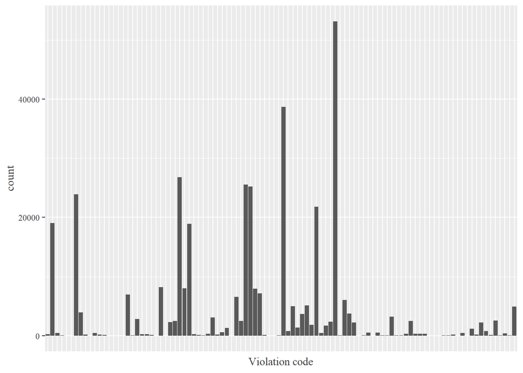

```r
df_raw %>%
  ggplot(aes(x = violation_code)) +
  geom_bar() +
  theme(text = element_text(
    family = "serif",
    color = "gray25"),
    axis.text.x = element_blank(),
    axis.ticks.x = element_blank()) +
  xlab("Violation code")
```

Because some of the violation types occur at low frequencies, we lump them into broader violation groups. Violations are either scored or unscored. Among scored violations, we have to distinguish between so called critical and general violations. Critical violations are deemed more severe than general violations and accordingly, are awarded more points than general violations. We end up with the self-annotaed scored categories ‘vermin’, ‘facility’, ‘hygiene’, ‘food protection’, ‘food temperature’, and ‘food source’. Furthermore there are ‘other_scored’ and ‘not_scored’, denoting categories that encompass other scored categories and unscored violations, respectively.

```r
# New variable violation_group:
df_raw <-
  df_raw %>%
  mutate(violation_group = case_when(
    violation_code %in% str_c("02", LETTERS[1:10]) ~ "food_temperature",
    violation_code %in% c(str_c("03", LETTERS[1:7]), str_c("09", LETTERS[1:3])) ~ "food_source",
    violation_code %in% str_c("04", LETTERS[1:10]) ~ "food_protection",
    violation_code %in% c(str_c("05", LETTERS[1:9]), str_c("10", LETTERS[1:10])) ~ "facility",
    violation_code %in% str_c("06", LETTERS[1:9]) ~ "hygiene",
    violation_code %in% str_c("04", LETTERS[11:15]) ~ "vermin",
    violation_code %in% c("07A", "99B") ~ "other_scored",
    !is.na(violation_code) ~ "not_scored"
  )
)
```

Here is a plot displaying the distribution:

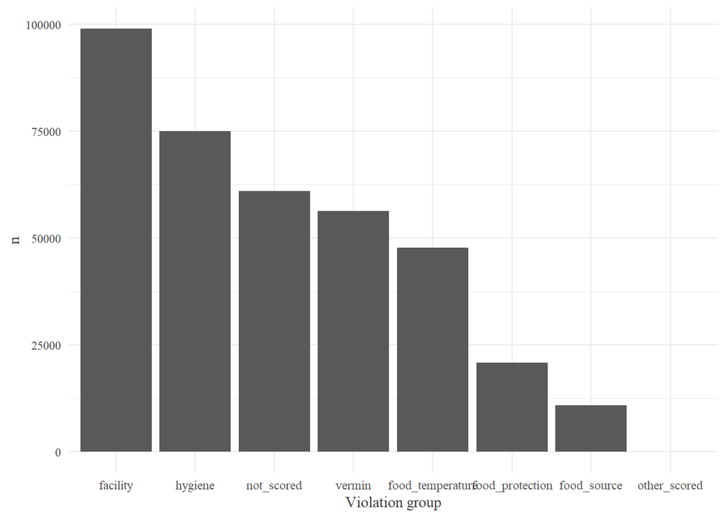

```r
df_raw %>%
  group_by(violation_group) %>%
  filter(!is.na(violation_group)) %>%
  summarize(n = n()) %>%
  ggplot(aes(reorder(violation_group, -n), n)) +
  geom_bar(stat = "identity") +
  theme(text = element_text(
    family = "serif",
    color = "gray25"),
    axis.text.x = element_text(angle = 60, hjust = 1)) +
  xlab("Violation group") +
  theme_minimal() +
  theme(
    text = element_text(
      family = "serif",
      color = "gray25"
    )
  )
```

We see that the most frequent category is ‘facility’, followed by ‘hygiene’ and ‘not_scored’.

Here is the distribution of violation code again. This time, we color the bars by the violation group that the respective violation belongs to.

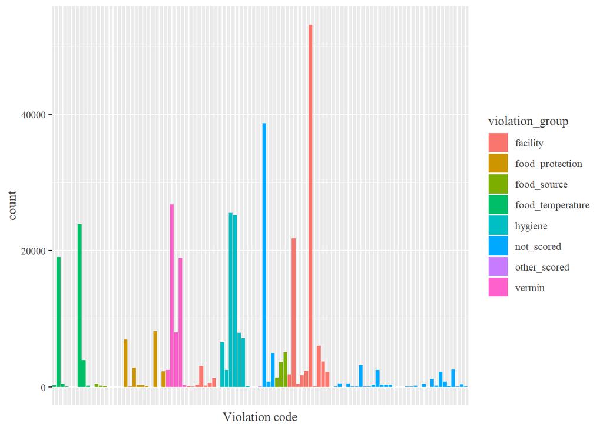

```r
df_raw %>%
  filter(!is.na(violation_group)) %>%
  ggplot(aes(x = violation_code, fill = violation_group)) +
  geom_bar() +
  theme(text = element_text(
    family = "serif",
    color = "gray25"),
    axis.text.x = element_blank(),
    axis.ticks.x = element_blank()) +
  xlab("Violation code")
```

For later use, we construct indicator variables for the different violation groups.

```r
df_raw <- df_raw %>%
  # Create indicator variables for levels of 'violation_group'
    mutate(viol_vermin = case_when(violation_group == "vermin" ~ 1, TRUE ~ 0),
           viol_not_scored = case_when(violation_group == "not_scored" ~ 1, TRUE ~ 0),
           viol_facility = case_when(violation_group == "facility" ~ 1, TRUE ~ 0),
           viol_food_temperature = case_when(violation_group == "food_temperature" ~ 1, TRUE ~ 0),
           viol_hygiene = case_when(violation_group == "hygiene" ~ 1, TRUE ~ 0),
           viol_food_protection = case_when(violation_group == "food_protection" ~ 1, TRUE ~ 0),
           viol_food_source = case_when(violation_group == "food_source" ~ 1, TRUE ~ 0),
           viol_other_scored = case_when(violation_group == "other_scored"  ~ 1, TRUE ~ 0)
    )
```

## 2.6 Inspection types

The variable inspection type takes on 34 distinct values. Here we show ten of those values.

```r
df_raw %>%
  distinct(inspection_type) %>%
  slice(1:10)
```

| inspection_type |
| --- |
| Pre-permit (Operational) / Re-inspection |
| Administrative Miscellaneous / Initial Inspection |
| Pre-permit (Operational) / Initial Inspection |
| Cycle Inspection / Re-inspection |
| Cycle Inspection / Initial Inspection |
| Administrative Miscellaneous / Re-inspection |
| Trans Fat / Initial Inspection |
| Pre-permit (Operational) / Compliance Inspection |
| Cycle Inspection / Reopening Inspection |
| Smoke-Free Air Act / Re-inspection |

As with the violation type, we lump some of these values together. We obtain the following values:

```r
df_raw <- df_raw %>%
  separate(inspection_type, into = c("before_slash", "after_slash"), sep = " / ") %>%
    mutate(after_slash = str_replace_all(after_slash, fixed(" "), fixed(""))) %>%
    mutate(inspection_type2 = str_replace_all(after_slash, fixed("-i"), fixed("I")))

df_raw %>%
  distinct(inspection_type2)
```

| inspection_type2 |
| --- |
| ReInspection |
| InitialInspection |
| ComplianceInspection |
| ReopeningInspection |
| SecondComplianceInspection |
| LimitedInspection |

Here is a display of the distribution:

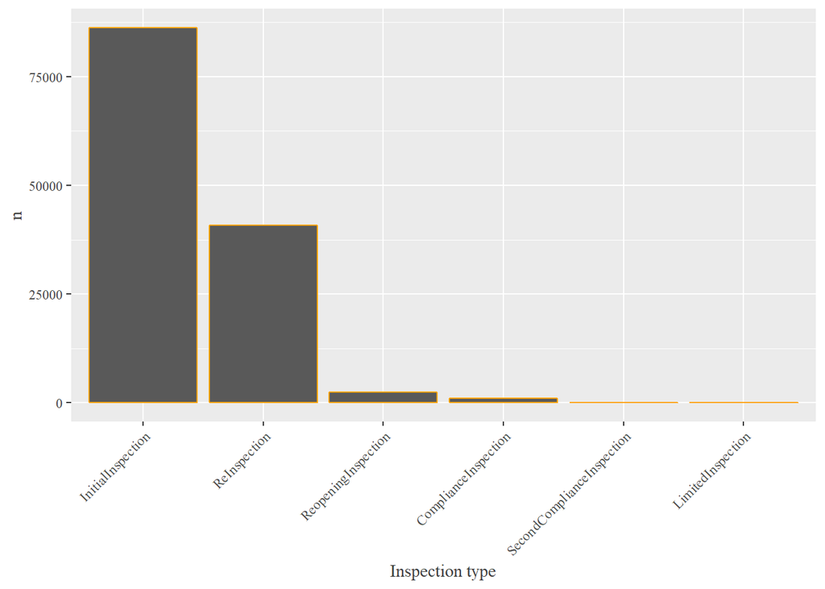

```r
df_raw %>%
  group_by(inspection_type2) %>%
  summarise(n = n_distinct(id, inspection_date)) %>%
  ggplot(aes(reorder(as.factor(inspection_type2), -n), n)) +
  geom_bar(stat = "identity", color = "orange") +
  xlab("Inspection type") +
  theme(text = element_text(
      family = "serif",
      color = "gray25"),
      axis.text.x = element_text(angle = 45, hjust = 1))
```

Again, there a are categories that are ‘almost empty’. The vast majority of observations are initial and re-inspections: 86306 and 40831, respectively.

```r
df_raw %>%
  group_by(inspection_type2) %>%
  summarise(n = n_distinct(id, inspection_date)) %>%
  arrange(desc(n))
```

| inspection_type2 | n |
| --- | --- |
| InitialInspection | 86306 |
| ReInspection | 40831 |
| ReopeningInspection | 2496 |
| ComplianceInspection | 1102 |
| SecondComplianceInspection | 78 |
| LimitedInspection | 4 |

For later purposes, we construct a dummy variable for the category ‘InitialInspection’.

```r
df_raw <- df_raw %>%
  mutate(dummy_InitialInspection = case_when(
      inspection_type2 == "InitialInspection" ~ "Initial",
      TRUE ~ "Not_Initial"
    ))
```

## 2.7 Grade

Next, we investigate the variable ‘grade’.

```r
df_raw %>%
  group_by(grade) %>%
  summarise(n = n()) %>%
  arrange(desc(n))
```

| grade | n |
| --- | --- |
| NA | 187702 |
| A | 149897 |
| B | 24696 |
| C | 6318 |
| Z | 3510 |
| Not Yet Graded | 1915 |
| P | 1751 |

There is a massive amount of NA’s. We are going to investigate how the number of NAs for ‘grade’ relates to ‘score’ and ‘inspection type.’ More precisely, we know that on initial inspections no grade is issued, if the corresponding score is above 14. It seems plausible that this would lead to a value of NA for ‘grade’.

```r
df_raw %>%
  select(inspection_type2, score, grade) %>%
  filter(inspection_type2 == "InitialInspection", score > 14) %>%
  group_by(grade) %>%
  summarise(n = n())
```

| grade | n |
| --- | --- |
| Not Yet Graded | 1548 |
| NA | 137410 |

So about 73 % of the missing values for grade are a consequence of a score of 14 or higher. Furthermore, out of the 1915 observations with value ‘Not yet graded’, 1548 are the result of a high score (above 13) in the initial inspection. We will recode these NA’s to “Not Yet Graded” to reduce the number of missing values for ‘grade’.

```r
# Recode NA's with inspection type = 'InitialInspection' and 'score' > 14 to "Not Yet Graded":
df_raw <- df_raw %>%
  mutate(grade = case_when(
    is.na(.$grade) &
      .$inspection_type2 == "InitialInspection" &
      .$score > 14 ~ "Not Yet Graded",
    TRUE ~ grade
  ))
```

This reduces the number of NA’s to 13 %:

```r
df_raw %>%
  summarise(prop_na = round(mean(is.na(grade)), 2),
            n_not_graded = sum(grade == "Not Yet Graded", na.rm = T))
```

| prop_na | n_not_graded |
| --- | --- |
| 0.13 | 139325 |

Here is the distribution of the proportion of inspections with an NA for grade per restaurant:

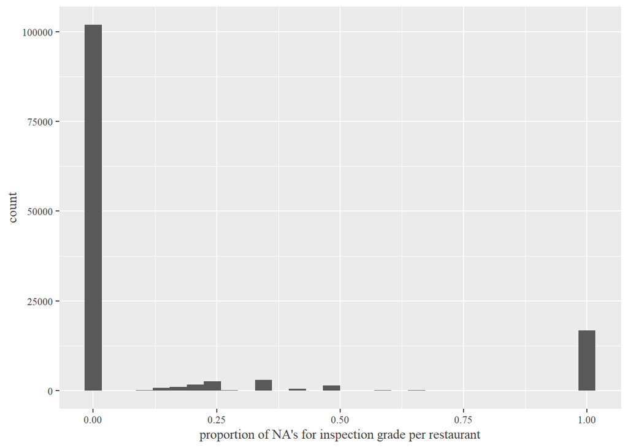

```r
df_raw %>%
  group_by(id, inspection_date) %>%
  summarise(prop_gradeNA = mean(is.na(grade))) %>%
  ggplot(aes(x = prop_gradeNA)) +
  geom_histogram(bins = 30) +
  xlab("proportion of NA's for inspection grade per restaurant") +
  theme(
    text = element_text(
      family = "serif",
      color = "gray25"
    )
  )
```

It seems that for most restaurants there is no inspection with a missing value for grade. On the other hand, there are some restaurants for whom all values for grade are NA.

```r
df_raw %>%
  group_by(id, inspection_date) %>%
  summarise(prop_gradeNA = round(mean(is.na(grade)), 3)) %>%
  ungroup() %>%
  group_by(prop_gradeNA) %>%
  summarise(proportion_of_restaurants = round(n()/nrow(.), 3)) %>%
  arrange(desc(proportion_of_restaurants)) %>%
  slice(1:10)
```

| prop_gradeNA | proportion_of_restaurants |
| --- | --- |
| 0.000 | 0.781 |
| 1.000 | 0.128 |
| 0.333 | 0.024 |
| 0.250 | 0.020 |
| 0.200 | 0.012 |
| 0.500 | 0.011 |
| 0.167 | 0.008 |
| 0.143 | 0.004 |
| 0.400 | 0.003 |
| 0.125 | 0.002 |

## 2.8 Score

Let us turn to ‘score’.

```r
df_raw %>%
  pull(score) %>%
  summary()
```

```
##    Min. 1st Qu.  Median    Mean 3rd Qu.    Max.    NA's
##   -2.00   11.00   14.00   18.93   24.00  151.00   19514
```

There are 19514 NA’s. So let us look at the proportion of inspections that exhibit an NA for ‘score’.

```r
df_raw %>%
  group_by(id, inspection_date) %>%
  summarise(n_na = sum(is.na(score))) %>%
  ungroup() %>%
  summarise(n_na = round(sum(n_na)/n(), 3))
```

| n_na |
| --- |
| 0.15 |

15 % of all inspections have a missing value for ‘score’.

We know that there are 61028 observations that refer to violations that are not scored:

```r
df_raw %>%
  group_by(violation_group) %>%
  summarise(n = n()) %>%
  filter(violation_group == "not_scored")
```

| violation_group | n |
| --- | --- |
| not_scored | 61028 |

These observations are expected to have an NA for ‘score’:

```r
df_raw %>%
  select(violation_group, score) %>%
  filter(violation_group == "not_scored") %>%
  summarise(n = n(), n_na_score = sum(is.na(score)), prop_na_score = round(n_na_score/n, 2))
```

| n | n_na_score | prop_na_score |
| --- | --- | --- |
| 61028 | 16086 | 0.26 |

Hence, these 16086 observations account for 82 % of all of the 19514 NA’s for ‘score’. What about the remaining 3428 missing values for ‘score’? Let us consider the relationship with violation group:

```r
df_raw %>%
  select(violation_group, score) %>%
  filter(is.na(violation_group)) %>%
  summarise(n = n(), n_na_score = sum(is.na(score)))
```

| n | n_na_score |
| --- | --- |
| 4921 | 3428 |

Hence, the rest of the NA’s for score are associated with NA’s on ‘violation_group’. So let us turn to the NA’s for the variable ‘violation_group’. One cause for an NA here may be that on a given inspection, there was no violation at all. So what is the number of NA’s for violation group among observations that do not exhibit a violation?

```r
df_raw %>%
  filter(action == "NoViol") %>%
  summarise(viol_group_NA = sum(is.na(violation_group)))
```

| viol_group_NA |
| --- |
| 4634 |

# 3 Predicting time until the next inspection

Finally, we turn to the question posed in the beginning, namely, whether it is possible to predict the number of days until the next inspection, using the variables described above.

## 3.1 Split into training and test data

```r
set.seed(1)
train_ids <- sample(unique(df_raw$id), 0.6*length(unique(df_raw$id)))
test_ids <- setdiff(unique(df_raw$id), train_ids)
```

Next, we have to make sure that the distributions of the target feature in training and test data are reasonably similar:

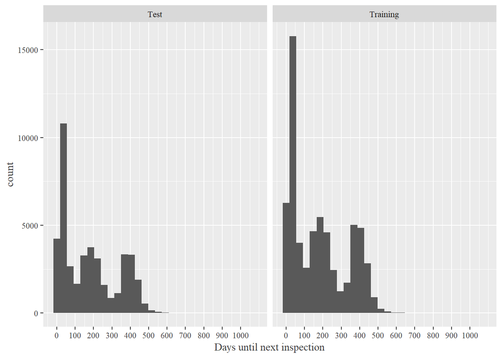

```r
df_raw %>%
  select(id, inspection_date) %>%
  group_by(id, inspection_date) %>%
  arrange(inspection_date) %>%
  summarise() %>%
  mutate(difference = lead(inspection_date) - inspection_date) %>%
  filter(!is.na(difference)) %>%
  mutate(group = ifelse(id %in% train_ids, "Training", "Test")) %>%
  ggplot(aes(as.numeric(difference))) +
  geom_histogram(bins = 30) +
  scale_x_continuous(breaks = seq(0, 1000, by = 100)) +
  xlab("Days until next inspection") +
  facet_grid(. ~ group) +
  theme(
    text = element_text(
      family = "serif",
      color = "gray25"
    )
  )
```

The distribution of the target seems reasonably similar across training and test data.

## 3.2 Features

Next, we will construct features using the variables in the data set. The result of that construction will be a table, where each row corresponds to an inspection for a given restaurant, containing

- the grade of the inspection (*grade*),
- an indicator whether the row corresponds to an initial inspection(*dummy_InitialInspection*),
- the score of the inspection (*score*),
- the cuisine of the restaurant (*cuisine_descr*),
- the number of violations in the different violation_groups (*viol_*), and
- the number of critical flags,
- the number of days until the next inspection (*days_until_next*) which is to be used only in the training data

```r
## Create data set with features for inspection type, score, grade and number of violations:

## Make feature set:

make_features_raw <- function ( df ) {

  df %>%
    select ( id, inspection_date, dummy_InitialInspection, score,
             grade, cuisine_descr ) %>%
    group_by ( id, inspection_date ) %>%
    arrange ( id, inspection_date ) %>%
    summarise_at ( vars(c("grade","dummy_InitialInspection", "score", "cuisine_descr")),
                   .funs = list(first) ) %>%
    left_join (
      df %>%
        select ( id, inspection_date, starts_with("viol_"), starts_with("critical") ) %>%
        mutate( critical_flag = case_when( critical_flag == "Critical" ~ 1,
                                           TRUE ~ 0 ) ) %>%
        group_by ( id, inspection_date ) %>%
        arrange ( id, inspection_date ) %>%
        summarise_at ( vars(starts_with( "viol" ), starts_with( "critical" ) ),
                       ~ sum( ., na.rm = TRUE ) ),
      by = c ( "id", "inspection_date" ) ) %>%
    ungroup()

}

# Add target feature

add_target_feature <- function(df) {

  df %>%
    group_by(id) %>%
    arrange(id, inspection_date) %>%
    mutate ( days_until_next = lead ( inspection_date ) - inspection_date ) %>%
    filter(!is.na(days_until_next)) %>%
    ungroup() %>%
    mutate ( days_until_next_categ = case_when (
      between ( as.numeric ( days_until_next ), 0, 100 ) ~ "within 2 to 3 months",
      between ( as.numeric ( days_until_next ), 101, 300 ) ~ "within 10 months",
      TRUE ~ "in more than 10 months" ),
      days_until_next_categ = as.factor ( days_until_next_categ ) ) %>%
    ungroup()

}
```

As we have seen in the exploration, there is a number of NA’s for the features *grade* and *score*. Because the prediction algorithms that we will employ require that there be no missing values, we will impute these values. To impute *score* (*grade*), we will train a regression tree (classification tree) to predict *score* (*grade*) using all the other features on all rows where *score* (*grade*) is not missing.

```r
# Impute features

impute_features <- function ( df ) {

  df %>%
    filter(is.na(score)) %>%
    mutate(score = predict(df %>%
                             filter ( !is.na ( score ) ) %>%
                             select ( score, grade, dummy_InitialInspection, cuisine_descr,
                                      starts_with ( "viol_" ), critical_flag ) %>%
                             rpart ( score ~ ., data = ., method = "anova" ), .)) %>%
    bind_rows(df %>% filter(!is.na(score))) %>%
    filter(is.na(grade)) %>%
    mutate(grade = predict(df %>%
                             filter ( !is.na ( grade ) ) %>%
                             select ( score, grade, dummy_InitialInspection, cuisine_descr,
                                      starts_with ( "viol_" ), critical_flag ) %>%
                             rpart ( grade ~ ., data = ., method = "class" ), ., type = "class"),
           grade = as.character(grade)) %>%
    bind_rows(df %>%
                filter(!is.na(grade)))

}
```

As alluded to above, for the training data we add in *days_until_next*.

```r
df_features <- df_raw %>%
  make_features_raw() %>%
  impute_features()

df_train <- df_features %>% filter(id %in% train_ids) %>% add_target_feature()
df_test <- df_features %>% filter(id %in% test_ids)
```

For now, the test data will be removed from the session. Later, we will use it to evaluate the final model.

```r
saveRDS(df_test, "df_test.rds")
rm(df_test)
```

## 3.3 Feature Exploration

Let us first explore a couple of bivariate relationships between the predictors and the target feature. We will begin with the relationship between grade and days until the next inspection

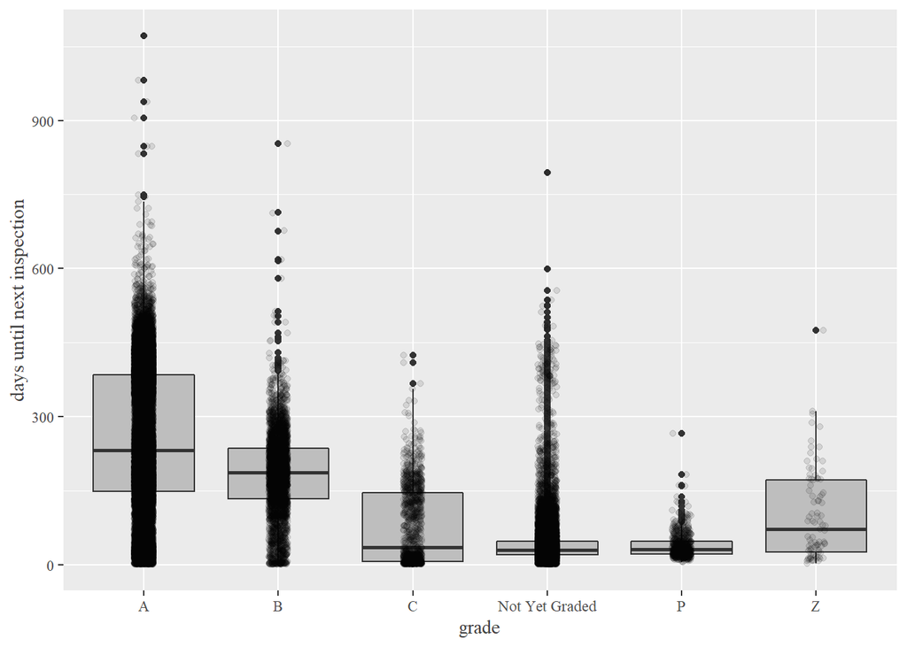

```r
df_train %>%
  ggplot ( aes ( x = grade, y = as.numeric ( days_until_next ) ) ) +
  geom_boxplot ( fill = "grey") +
  geom_jitter(alpha = .1, width = .07) +
  xlab("grade") +
  ylab("days until next inspection") +
  theme(
    text = element_text(
      family = "serif",
      color = "gray25"
    )
  )
```

As we can see, the median number of days until the next inspection decreases when moving from A to C. This is not suprising, since a good grade on the initial inspection reduces the likelihood of being subjected to a re-inspection the same inspection cycle.

Let us move on to the relationship between violation types and the target feature:

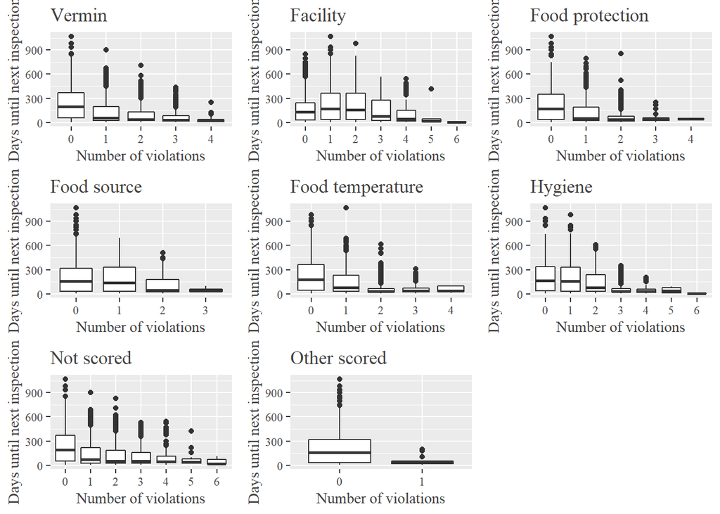

```r
g_vermin <- df_train %>%
  ggplot(aes(x = as.factor(viol_vermin), y = as.numeric(days_until_next))) +
  geom_boxplot() +
  xlab("Number of violations") +
  ylab("Days until next inspection") +
  theme(
    text = element_text(
      family = "serif",
      color = "gray25"
    )
  ) +
  ggtitle("Vermin")

g_not_scored <- df_train %>%
  ggplot(aes(x = as.factor(viol_not_scored), y = as.numeric(days_until_next))) +
  geom_boxplot() +
  xlab("Number of violations") +
  ylab("Days until next inspection") +
  theme(
    text = element_text(
      family = "serif",
      color = "gray25"
    )
  ) +
  ggtitle("Not scored")

g_facility <- df_train %>%
  ggplot(aes(x = as.factor(viol_facility), y = as.numeric(days_until_next))) +
  geom_boxplot() +
  xlab("Number of violations") +
  ylab("Days until next inspection") +
  theme(
    text = element_text(
      family = "serif",
      color = "gray25"
    )
  ) +
  ggtitle("Facility")

g_food_temperature <- df_train %>%
  ggplot(aes(x = as.factor(viol_food_temperature), y = as.numeric(days_until_next))) +
  geom_boxplot() +
  xlab("Number of violations") +
  ylab("Days until next inspection") +
  theme(
    text = element_text(
      family = "serif",
      color = "gray25"
    )
  ) +
  ggtitle("Food temperature")

g_hygiene <- df_train %>%
  ggplot(aes(x = as.factor(viol_hygiene), y = as.numeric(days_until_next))) +
  geom_boxplot() +
  xlab("Number of violations") +
  ylab("Days until next inspection") +
  theme(
    text = element_text(
      family = "serif",
      color = "gray25"
    )
  ) +
  ggtitle("Hygiene")

g_food_protection <- df_train %>%
  ggplot(aes(x = as.factor(viol_food_protection), y = as.numeric(days_until_next))) +
  geom_boxplot() +
  xlab("Number of violations") +
  ylab("Days until next inspection") +
  theme(
    text = element_text(
      family = "serif",
      color = "gray25"
    )
  ) +
  ggtitle("Food protection")

g_food_source <- df_train %>%
  ggplot(aes(x = as.factor(viol_food_source), y = as.numeric(days_until_next))) +
  geom_boxplot() +
  xlab("Number of violations") +
  ylab("Days until next inspection") +
  theme(
    text = element_text(
      family = "serif",
      color = "gray25"
    )
  ) +
  ggtitle("Food source")

g_other_scored <- df_train %>%
  ggplot(aes(x = as.factor(viol_other_scored), y = as.numeric(days_until_next))) +
  geom_boxplot() +
  xlab("Number of violations") +
  ylab("Days until next inspection") +
  theme(
    text = element_text(
      family = "serif",
      color = "gray25"
    )
  ) +
  ggtitle("Other scored")

grid.arrange(g_vermin, g_facility,
             g_food_protection, g_food_source, g_food_temperature,
             g_hygiene, g_not_scored, g_other_scored, ncol = 3)
```

Here also, as expected, the median number of days until the next inspection decreases as the number of violations per inspection increases.

## 3.4 Linear Regression model

We start with a simple linear regression model, using all features.

```r
(lin_reg_model <- df_train %>%
    select(-days_until_next_categ, -id, -inspection_date) %>%
    train(as.numeric(days_until_next) ~ .,
          data = .,
          method = "lm"))
```

```
## Linear Regression
##
## 62767 samples
##    13 predictor
##
## No pre-processing
## Resampling: Bootstrapped (25 reps)
## Summary of sample sizes: 62767, 62767, 62767, 62767, 62767, 62767, ...
## Resampling results:
##
##   RMSE      Rsquared   MAE
##   109.2115  0.4772526  79.89751
##
## Tuning parameter 'intercept' was held constant at a value of TRUE
```

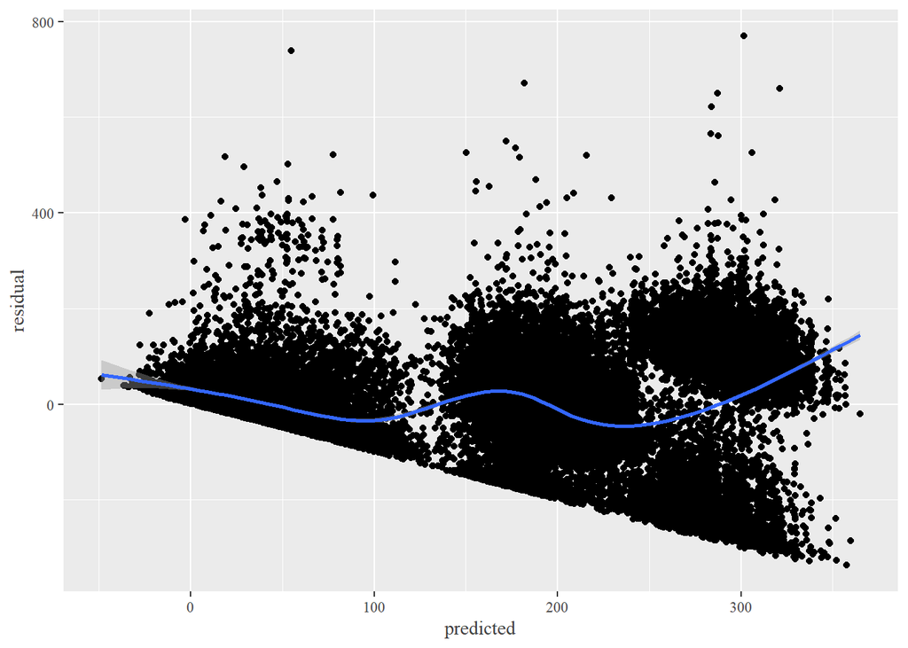

```r
df_lin_reg <- data_frame(actual = as.numeric(df_train$days_until_next),
                         predicted = as.numeric(predict(lin_reg_model, df_train)),
                         residual = actual - predicted)

df_lin_reg %>%
  ggplot(aes(x = predicted, y = residual)) +
  geom_point() +
  geom_smooth() +
  theme(
    text = element_text(
      family = "serif",
      color = "gray25"
    )
  )
```

There are a few curious things to notice about the plot. First, apparently there is a set of restaurants for which the model predicts a negative duration until the next inspection, which does not make sense. Second, there seems to be some pattern in the residuals. In the presence of nonlinearities, the conclusions drawn from the fit are questionable. At this point, one could investigate how these patterns in the residuals come about. Instead, in the next section, we will fit a nonlinear regression model to the data.

## 3.5 Regression tree

The linear regression model didn’t perform well. The residual plot suggests that a linear model may not be appropriate model. Hence, we will use a more flexible model and fit a regression tree model. First, we set the hyperparameters:

```r
# Set hyperparameters for cross-validated classification and regression tree
set.seed(42)
myControl <- trainControl(

  method = "cv",
  number = 10

)
cp.grid <- expand.grid(.cp = (1:10)*0.01)
```

Then we fit the model, employing 10-fold cross validation:

```r
set.seed(3333)
(reg_tree_model <- df_train %>% select(-days_until_next_categ, -id, -inspection_date) %>%
    train(as.numeric(days_until_next) ~ .,
          data = .,
          method = "rpart",
          trControl = myControl,
          tuneGrid = cp.grid))
```

```
## CART
##
## 62767 samples
##    13 predictor
##
## No pre-processing
## Resampling: Cross-Validated (10 fold)
## Summary of sample sizes: 56490, 56489, 56491, 56491, 56490, 56492, ...
## Resampling results across tuning parameters:
##
##   cp    RMSE      Rsquared   MAE
##   0.01  105.5183  0.5123524  72.32293
##   0.02  110.5336  0.4648770  77.94083
##   0.03  110.5336  0.4648770  77.94083
##   0.04  113.9228  0.4315671  82.14456
##   0.05  113.9228  0.4315671  82.14456
##   0.06  113.9228  0.4315671  82.14456
##   0.07  113.9228  0.4315671  82.14456
##   0.08  113.9228  0.4315671  82.14456
##   0.09  122.2085  0.3458682  93.62115
##   0.10  122.2085  0.3458682  93.62115
##
## RMSE was used to select the optimal model using the smallest value.
## The final value used for the model was cp = 0.01.
```

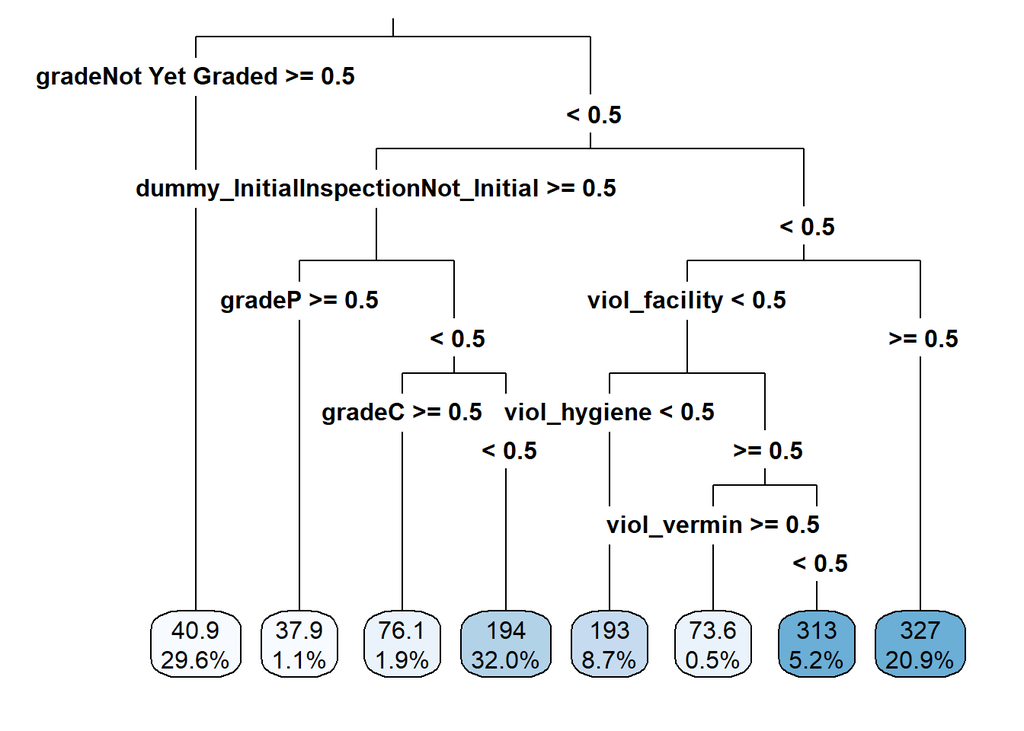

```r
library(rpart.plot)
rpart.plot ( reg_tree_model$finalModel, type = 3, digits = 3, fallen.leaves = TRUE )
```

The model has a slightly higher R squared than the linear regression model. Nevertheless, the fit of the regression to the training data is quite poor.

## 3.6 Reformulating the problem: Classification

As we have seen, linear regression and regression trees did a poor job of predicting the number of days until the next inspection. So next, but we will rephrase the problem. Instead of predicting the number of days, we could give a time interval into which the next inspection will fall. We have already constructed a categorical variable that partitions the original range into the categories ‘within 2 to 3 months’, ‘within 10 months’ and ‘in more than 10 months’. The distribution of the new target in the training data looks like this:

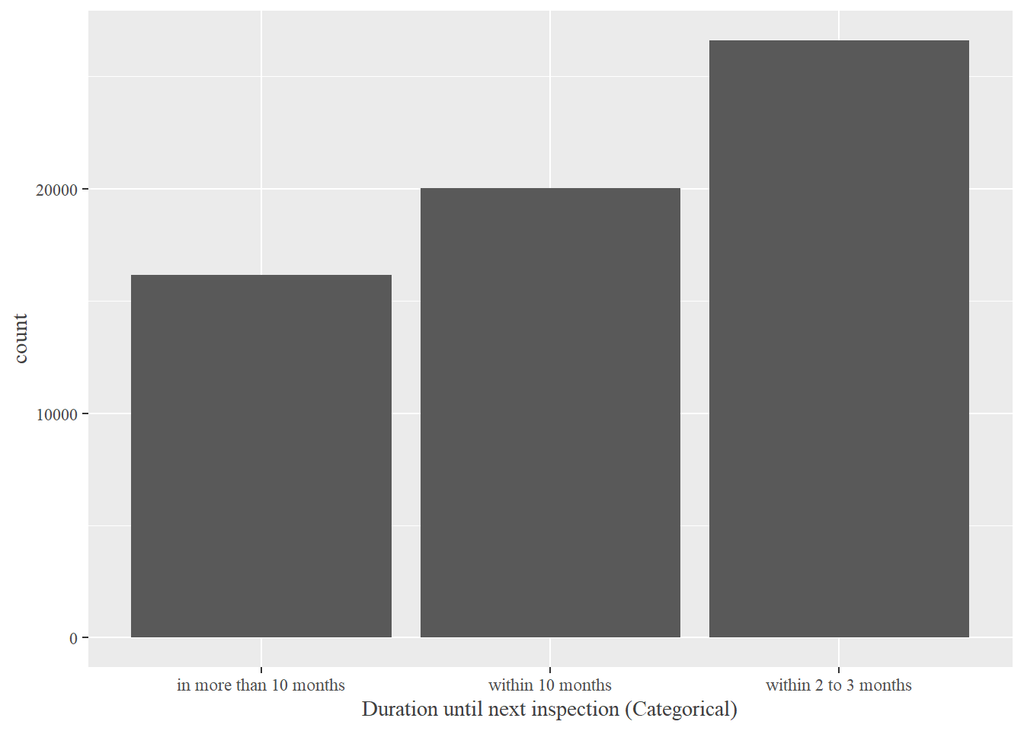

```r
df_train %>%
  ggplot(aes(days_until_next_categ)) +
  geom_bar() +
  xlab("Duration until next inspection (Categorical)") +
  theme(
    text = element_text(
      family = "serif",
      color = "gray25"
    )
  )
```

As we can see, for most inspections, the next inspection occurs within the next 2 to 3 months. Let us investigate bivariate relationships between some of the features and the new target:

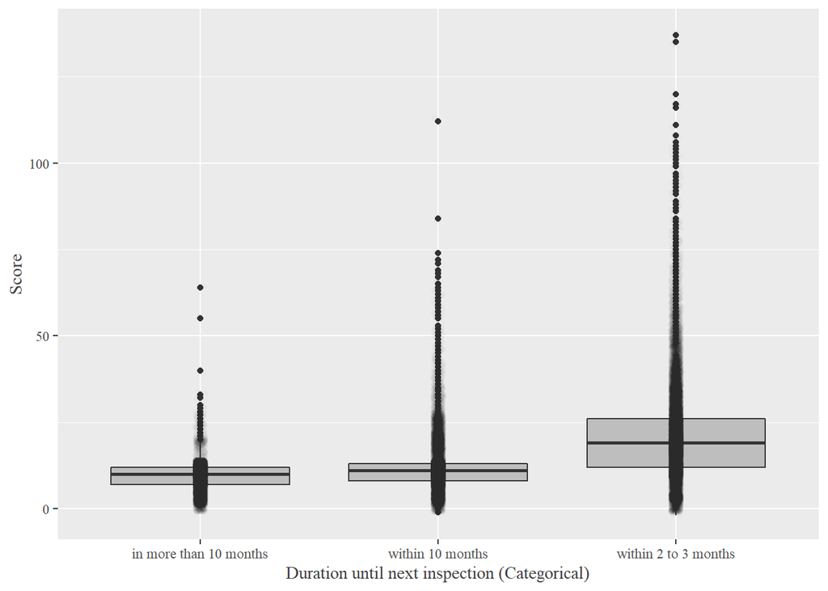

```r
df_train %>%
  ggplot ( aes ( x = days_until_next_categ, y = score ) ) +
  geom_boxplot ( fill = "grey") +
  geom_jitter(alpha = .01, width = .02, height = 1) +
  xlab("Duration until next inspection (Categorical)") +
  ylab("Score") +
  theme(
    text = element_text(
      family = "serif",
      color = "gray25"
    )
  )
```

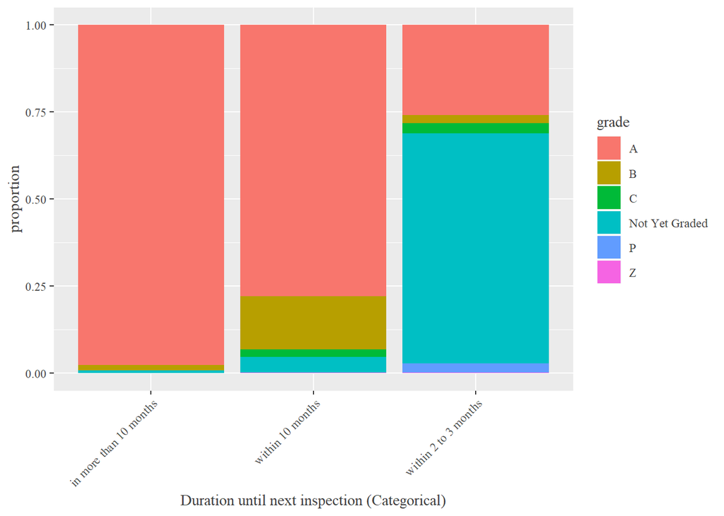

```r
df_train %>%
  ggplot ( aes ( x = days_until_next_categ , fill = grade) ) +
  geom_bar ( position = "fill" ) +
  ylab("proportion") +
  xlab("Duration until next inspection (Categorical)") +
  theme(
    text = element_text(
      family = "serif",
      color = "gray25"
    ),
    axis.text.x = element_text(angle = 45, hjust = 1)
  )
```

Not surprisingly, among those inspections for which the next inspection occurs within the next 2 to 3 months, the median score is higher than for the other two categories. Also, the proportion of inspections receiving an ‘A’ is higher among inspections where the duration until the next inspection is longer. This is also something we would expect.

### 3.6.1 Classification model

Next, we will fit a classification tree to the data, employing 10-fold cross validation:

```r
set.seed(3333)
(class_tree_model <- df_train %>% select(-days_until_next, -id, -inspection_date) %>%
    train(days_until_next_categ ~ .,
          data = .,
          method = "rpart",
          trControl = myControl,
          tuneGrid = cp.grid)
)
```

```
## CART
##
## 62767 samples
##    13 predictor
##     3 classes: 'in more than 10 months', 'within 10 months', 'within 2 to 3 months'
##
## No pre-processing
## Resampling: Cross-Validated (10 fold)
## Summary of sample sizes: 56491, 56490, 56490, 56490, 56490, 56491, ...
## Resampling results across tuning parameters:
##
##   cp    Accuracy   Kappa
##   0.01  0.8190449  0.7292110
##   0.02  0.8022049  0.7055543
##   0.03  0.8022049  0.7055543
##   0.04  0.8022049  0.7055543
##   0.05  0.8022049  0.7055543
##   0.06  0.8022049  0.7055543
##   0.07  0.8022049  0.7055543
##   0.08  0.8022049  0.7055543
##   0.09  0.8022049  0.7055543
##   0.10  0.8022049  0.7055543
##
## Accuracy was used to select the optimal model using the largest value.
## The final value used for the model was cp = 0.01.
```

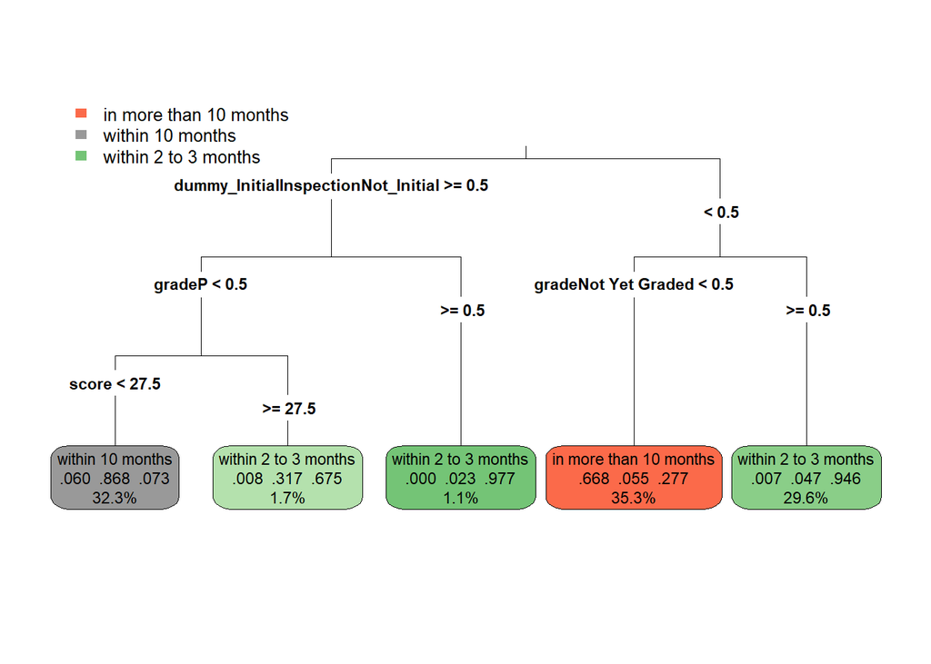

```r
rpart.plot ( class_tree_model$finalModel, type = 3, digits = 3, fallen.leaves = TRUE )
```

Looking at the tree, we see that, once we condition on whether the inspection at hand is initial or not, higher scores are associated with shorter time periods until the next inspection. Furthermore, looking at the left branch of the tree, non-initial inspections that are graded are predicted to be re-inspected within the next 2 to 3 months, provided the recored score is above 27.

The accuracy of the model is 0.819. Let us look at additional measures of performance:

```r
confusionMatrix(data = predict(class_tree_model, df_train),
                reference = df_train$days_until_next_categ)
```

```
## Confusion Matrix and Statistics
##
##                         Reference
## Prediction               in more than 10 months within 10 months
##   in more than 10 months                  14806             1212
##   within 10 months                         1209            17593
##   within 2 to 3 months                      130             1219
##                         Reference
## Prediction               within 2 to 3 months
##   in more than 10 months                 6138
##   within 10 months                       1471
##   within 2 to 3 months                  18989
##
## Overall Statistics
##
##                Accuracy : 0.8187
##                  95% CI : (0.8157, 0.8217)
##     No Information Rate : 0.4238
##     P-Value [Acc > NIR] : < 2.2e-16
##
##                   Kappa : 0.729
##  Mcnemar's Test P-Value : < 2.2e-16
##
## Statistics by Class:
##
##                      Class: in more than 10 months Class: within 10 months
## Sensitivity                                 0.9171                  0.8786
## Specificity                                 0.8423                  0.9373
## Pos Pred Value                              0.6683                  0.8678
## Neg Pred Value                              0.9670                  0.9428
## Prevalence                                  0.2572                  0.3190
## Detection Rate                              0.2359                  0.2803
## Detection Prevalence                        0.3530                  0.3230
## Balanced Accuracy                           0.8797                  0.9079
##                      Class: within 2 to 3 months
## Sensitivity                               0.7139
## Specificity                               0.9627
## Pos Pred Value                            0.9337
## Neg Pred Value                            0.8207
## Prevalence                                0.4238
## Detection Rate                            0.3025
## Detection Prevalence                      0.3240
## Balanced Accuracy                         0.8383
```

## 3.7 Evaluation of final model

Finally we evaluate the final model on the test data:

```r
df_test <- readRDS("df_test.rds") %>% add_target_feature()
confusionMatrix(data = predict(class_tree_model, df_test),
                reference = df_test$days_until_next_categ)
```

```
## Confusion Matrix and Statistics
##
##                         Reference
## Prediction               in more than 10 months within 10 months
##   in more than 10 months                   9879              824
##   within 10 months                          743            12039
##   within 2 to 3 months                       86              825
##                         Reference
## Prediction               within 2 to 3 months
##   in more than 10 months                 4174
##   within 10 months                        944
##   within 2 to 3 months                  12885
##
## Overall Statistics
##
##                Accuracy : 0.8208
##                  95% CI : (0.8172, 0.8245)
##     No Information Rate : 0.4246
##     P-Value [Acc > NIR] : < 2.2e-16
##
##                   Kappa : 0.7321
##  Mcnemar's Test P-Value : < 2.2e-16
##
## Statistics by Class:
##
##                      Class: in more than 10 months Class: within 10 months
## Sensitivity                                 0.9226                  0.8795
## Specificity                                 0.8423                  0.9412
## Pos Pred Value                              0.6640                  0.8771
## Neg Pred Value                              0.9699                  0.9425
## Prevalence                                  0.2526                  0.3228
## Detection Rate                              0.2330                  0.2839
## Detection Prevalence                        0.3509                  0.3237
## Balanced Accuracy                           0.8824                  0.9104
##                      Class: within 2 to 3 months
## Sensitivity                               0.7157
## Specificity                               0.9627
## Pos Pred Value                            0.9340
## Neg Pred Value                            0.8211
## Prevalence                                0.4246
## Detection Rate                            0.3039
## Detection Prevalence                      0.3254
## Balanced Accuracy                         0.8392
```

Hence, the performance of the model on the test data is similar to the perormance on the training data.

### 3.7.1 Conclusion

Our initial goal of predicting the number of days until the next inspection could not be attained. Instead, we rephrased the problem and turned it into a classification problem. Then, we fit a classification tree on the training data, employing cross validation. The resulting model also performed well on the test data. So eventually, we have provided our client with a device that predicts a time window the next inspection is likely to occur in.